# Practical Machine Learning - Prediction Project

## Data processing

The two datasets are loaded into the variables `testing` and `training`.

```r
library(caret)
```

```r
library(corrplot)

testing <- read.csv("pml-testing.csv")
training <- read.csv("pml-training.csv")
```

```r
dim(training)
```

```
## [1] 19622   160
```

By exploring the training dataset, we can realize that many of the variables have either `NA` or no values. Then, we skip the variables with many entries of such kind. Also, we need to exclude the first 7 variables, since they contain useless info for prediction purposes, resulting in a new training dataset with 53 variables (the outcome variable `classe` is one of them).

```r
training[training==""] <- NA
col_NA <- rep(FALSE, ncol(training))

for (i in 1:ncol(training)) {
    if(sum(is.na(training[,i])) > 50) {
        col_NA[i] <- TRUE
    }
}

training_filter_na <- training[,!col_NA]
training_filter_na <- training_filter_na[,-1:-7]

dim(training_filter_na)
```

```
## [1] 19622    53
```

## Cross validation dataset

For cross-validation purposes, the obtained training dataset into two sub-datasets: a training one, containing 70% of the observations that is used to generate the model, and another one, with 30% of the observations, for a further cross-validation step. The aim of the cross-validation step is to assess the accuracy of the prediction model designed with the training dataset.

```r
set.seed(145)
training_index <- createDataPartition(training_filter_na$classe, p=0.7, list=FALSE)

training_filter_na_2 <- training_filter_na[training_index,]
cross_validation <- training_filter_na[-training_index,]
```

## Correlation inspection

We analyze the correlation between the 53 variables in the training dataset. Variables with a strong correlation with others hardly contribute to improve the predictor’s performance and may cause overfitting. Therefore, these variables need to be excluded.

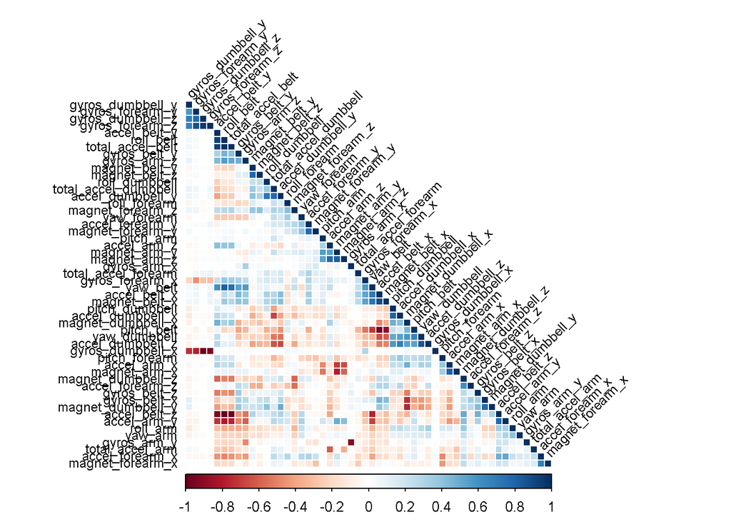

```r
correlation <- cor(training_filter_na_2[,-dim(training_filter_na_2)[2]],)
corrplot(correlation, method="color", type="lower", order="hclust", tl.cex=0.75, tl.col="black", tl.srt=45)
```

The figure above shows graphically the correlation –with a dark color representing a high correlation– between the 53 variables. Variables with a absolute correlation over 0.5 with other variables are identified and skipped.

```r
correlation_high <- findCorrelation(correlation, cutoff=0.5)
training_filter_na_corr_2 <- training_filter_na_2[,-correlation_high]
```

The final training dataset has 22 variables (the outcome variable `classe` is one of them).

```r
dim(training_filter_na_corr_2)
```

```
## [1] 13737    22
```

## Training

We have designed a prediction model based on Random Forests. The Random Forests algorithm builds a lot of trees and averages them to reduce the variance. We have applied the cross validation method –with very low impact on accuracy.

```r
library(randomForest)
set.seed(57)
options <- trainControl(method="cv", number=2, allowParallel=TRUE)
model <- modFit_sub <- train(classe~., method="rf", data=training_filter_na_corr_2, trControl=options, importance=TRUE)
model
```

```
## Random Forest
##
## 13737 samples
##    21 predictor
##     5 classes: 'A', 'B', 'C', 'D', 'E'
##
## No pre-processing
## Resampling: Cross-Validated (2 fold)
##
## Summary of sample sizes: 6869, 6868
##
## Resampling results across tuning parameters:
##
##   mtry  Accuracy   Kappa      Accuracy SD  Kappa SD
##    2    0.9652032  0.9559614  0.005974638  0.007582292
##   11    0.9529735  0.9404843  0.005152303  0.006545431
##   21    0.9416901  0.9262255  0.004638718  0.005892361
##
## Accuracy was used to select the optimal model using  the largest value.
## The final value used for the model was mtry = 2.
```

We can analyze the influence of the variables on the prediction model through a Variable Importance plot.

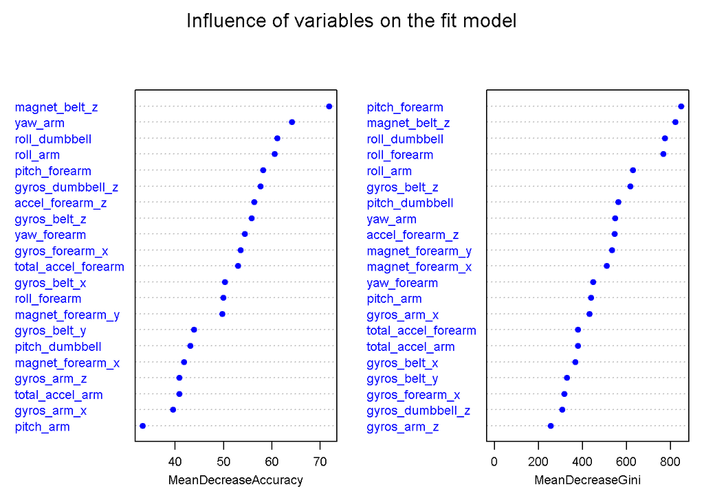

```r
varImpPlot(model$finalModel, main="Influence of variables on the fit model", pch=19, col="blue",cex=0.75, sort=TRUE)
```

## Cross validation

The model is tested upon the cross-validation dataset, so we can evaluate the model’s accuracy by comparing the predicted outcomes against the actual ones. The model exhibits an accuracy of 98.4%; thus, the out-of-sample error turns out to be 1.6%.

```r
pred_cv <- predict(model, newdata=cross_validation)

conf_mat <- confusionMatrix(pred_cv, cross_validation$classe)
conf_mat$table
```

```
##           Reference
## Prediction    A    B    C    D    E
##          A 1670   13    1    0    0
##          B    3 1116   11    1    1
##          C    0    9 1003   37    0
##          D    0    0    7  924    2
##          E    1    1    4    2 1079
```

```r
accuracy <- conf_mat$overall[1]
accuracy
```

```
##  Accuracy
## 0.9841971
```

## Predictions on the testing dataset

Finally, we apply the model on the testing dataset.

```r
testing_prediction <- predict(model, newdata=testing)
testing_prediction
```

```
##  [1] B A B A A E D B A A B C B A E E A B B B
## Levels: A B C D E
```